# EasyVisa_Full_Code_Notebook_1

## Hyperparameter Tuning

**Best practices for hyperparameter tuning in AdaBoost:**

`n_estimators`:

`learning_rate`:

- Common values to try: 1.0, 0.5, 0.1, 0.01
- Use 1.0 for faster training, suitable for fewer estimators
- Use 0.1 or 0.01 when using more estimators to improve generalization
- Avoid very small values (< 0.01) unless you plan to use many estimators (e.g., >500) and have sufficient data

**Best practices for hyperparameter tuning in Random Forest:**

`n_estimators`:

- Start with a specific number (50 is used in general) and increase in steps: 50, 75, 100, 125
- Higher values generally improve performance but increase training time
- Use 100-150 for large datasets or when variance is high

`min_samples_leaf`:

- Try values like: 1, 2, 4, 5, 10
- Higher values reduce model complexity and help prevent overfitting
- Use 1–2 for low-bias models, higher (like 5 or 10) for more regularized models
- Works well in noisy datasets to smooth predictions

`max_features`:

- Try values: `"sqrt"` (default for classification), `"log2"`, `None`, or float values (e.g., `0.3`, `0.5`)
- `"sqrt"` balances between diversity and performance for classification tasks
- Lower values (e.g., `0.3`) increase tree diversity, reducing overfitting
- Higher values (closer to `1.0`) may capture more interactions but risk overfitting

`max_samples` (for bootstrap sampling):

- Try float values between `0.5` to `1.0` or fixed integers
- Use `0.6–0.9` to introduce randomness and reduce overfitting
- Smaller values increase diversity between trees, improving generalization

**Best practices for hyperparameter tuning in Gradient Boosting:**

`n_estimators`:

- Start with 100 (default) and increase: 100, 200, 300, 500
- Typically, higher values lead to better performance, but they also increase training time
- Use 200–500 for larger datasets or complex problems
- Monitor validation performance to avoid overfitting, as too many estimators can degrade generalization

`learning_rate`:

- Common values to try: 0.1, 0.05, 0.01, 0.005
- Use lower values (e.g., 0.01 or 0.005) if you are using many estimators (e.g., > 200)
- Higher learning rates (e.g., 0.1) can be used with fewer estimators for faster convergence
- Always balance the learning rate with `n_estimators` to prevent overfitting or underfitting

`subsample`:

- Common values: 0.7, 0.8, 0.9, 1.0
- Use a value between `0.7` and `0.9` for improved generalization by introducing randomness
- `1.0` uses the full dataset for each boosting round, potentially leading to overfitting
- Reducing `subsample` can help reduce overfitting, especially in smaller datasets

`max_features`:

- Common values: `"sqrt"`, `"log2"`, or float (e.g., `0.3`, `0.5`)
- `"sqrt"` (default) works well for classification tasks
- Lower values (e.g., `0.3`) help reduce overfitting by limiting the number of features considered at each split

**Best practices for hyperparameter tuning in XGBoost:**

`n_estimators`:

- Start with 50 and increase in steps: 50,75,100,125.
- Use more estimators (e.g., 150-250) when using lower learning rates
- Monitor validation performance
- High values improve learning but increase training time

`subsample`:

- Common values: 0.5, 0.7, 0.8, 1.0
- Use `0.7–0.9` to introduce randomness and reduce overfitting
- `1.0` uses the full dataset in each boosting round; may overfit on small datasets
- Values < 0.5 are rarely useful unless dataset is very large

`gamma`:

- Try values: 0 (default), 1, 3, 5, 8
- Controls minimum loss reduction needed for a split
- Higher values make the algorithm more conservative (i.e., fewer splits)
- Use values > 0 to regularize and reduce overfitting, especially on noisy data

`colsample_bytree`:

- Try values: 0.3, 0.5, 0.7, 1.0
- Fraction of features sampled per tree
- Lower values (e.g., 0.3 or 0.5) increase randomness and improve generalization
- Use `1.0` when you want all features considered for every tree

`colsample_bylevel`:

- Try values: 0.3, 0.5, 0.7, 1.0
- Fraction of features sampled at each tree level (i.e., per split depth)
- Lower values help in regularization and reducing overfitting
- Often used in combination with `colsample_bytree` for fine control over feature sampling

### **We will apply hyperparameter tuning using:**

**(A) AdaBoost on SMOTE data**

**(B) RandomForest on Undersampled data**

**(C) GradientBoosting on SMOTE data**

**(D) XGBoost on SMOTE data**

**(E) DecisionTree on Original data**

#### **Hyperparameter Tuning: AdaBoost (SMOTE)**

```
Fitting 5 folds for each of 8 candidates, totalling 40 fits
[CV] END ................learning_rate=1.0, n_estimators=125; total time=   2.1s
[CV] END ................learning_rate=1.0, n_estimators=125; total time=   2.1s
[CV] END ................learning_rate=1.0, n_estimators=125; total time=   2.1s
[CV] END ................learning_rate=1.0, n_estimators=125; total time=   2.9s
[CV] END ................learning_rate=1.0, n_estimators=125; total time=   2.5s
[CV] END ................learning_rate=0.01, n_estimators=75; total time=   1.3s
[CV] END ................learning_rate=0.01, n_estimators=75; total time=   1.3s
[CV] END ................learning_rate=0.01, n_estimators=75; total time=   1.3s
[CV] END ................learning_rate=0.01, n_estimators=75; total time=   1.3s
[CV] END ................learning_rate=0.01, n_estimators=75; total time=   1.3s
[CV] END ................learning_rate=0.5, n_estimators=125; total time=   2.1s
[CV] END ................learning_rate=0.5, n_estimators=125; total time=   2.9s
[CV] END ................learning_rate=0.5, n_estimators=125; total time=   2.6s
[CV] END ................learning_rate=0.5, n_estimators=125; total time=   2.1s
[CV] END ................learning_rate=0.5, n_estimators=125; total time=   2.1s
[CV] END ................learning_rate=1.0, n_estimators=100; total time=   1.7s
[CV] END ................learning_rate=1.0, n_estimators=100; total time=   1.7s
[CV] END ................learning_rate=1.0, n_estimators=100; total time=   1.9s
[CV] END ................learning_rate=1.0, n_estimators=100; total time=   2.4s
[CV] END ................learning_rate=1.0, n_estimators=100; total time=   2.0s
[CV] END ................learning_rate=0.5, n_estimators=100; total time=   1.7s
[CV] END ................learning_rate=0.5, n_estimators=100; total time=   1.7s
[CV] END ................learning_rate=0.5, n_estimators=100; total time=   1.7s
[CV] END ................learning_rate=0.5, n_estimators=100; total time=   1.7s
[CV] END ................learning_rate=0.5, n_estimators=100; total time=   1.7s
[CV] END ................learning_rate=0.1, n_estimators=100; total time=   2.2s
[CV] END ................learning_rate=0.1, n_estimators=100; total time=   2.5s
[CV] END ................learning_rate=0.1, n_estimators=100; total time=   1.7s
[CV] END ................learning_rate=0.1, n_estimators=100; total time=   1.7s
[CV] END ................learning_rate=0.1, n_estimators=100; total time=   1.7s
[CV] END .................learning_rate=0.5, n_estimators=50; total time=   0.9s
[CV] END .................learning_rate=0.5, n_estimators=50; total time=   0.8s
[CV] END .................learning_rate=0.5, n_estimators=50; total time=   0.9s
[CV] END .................learning_rate=0.5, n_estimators=50; total time=   0.9s
[CV] END .................learning_rate=0.5, n_estimators=50; total time=   0.9s
[CV] END .................learning_rate=1.0, n_estimators=75; total time=   1.6s
[CV] END .................learning_rate=1.0, n_estimators=75; total time=   2.7s
[CV] END .................learning_rate=1.0, n_estimators=75; total time=   1.4s
[CV] END .................learning_rate=1.0, n_estimators=75; total time=   1.3s
[CV] END .................learning_rate=1.0, n_estimators=75; total time=   1.3s
Best AdaBoost (SMOTE) params: {'n_estimators': 75, 'learning_rate': 1.0}
Best AdaBoost (SMOTE) CV F1: 0.8031258929368361

AdaBoost_Tuned_SMOTE — Validation Confusion Matrix:
```

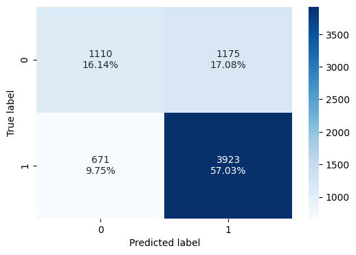

```
AdaBoost_Tuned_SMOTE — Test Confusion Matrix:
```

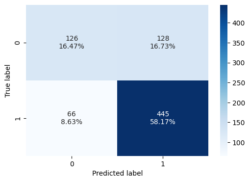

```python
param_dist_ada = {
    "n_estimators": [50, 75, 100, 125],
    "learning_rate": [1.0, 0.5, 0.1, 0.01],
}
ada = AdaBoostClassifier(random_state=1)

# Define the F1 scorer
f1_scorer = make_scorer(f1_score, pos_label=1)

# Run RandomizedSearchCV (single‐process to avoid pickling issues)
rs_ada = RandomizedSearchCV(
    estimator=ada,
    param_distributions=param_dist_ada,
    scoring=f1_scorer,
    n_iter=8,
    cv=StratifiedKFold(n_splits=5, shuffle=True, random_state=1),
    random_state=1,
    n_jobs=1,
    verbose=2,
)

# Fit on SMOTE‐oversampled training data (X_train_sm, y_train_sm)
rs_ada.fit(X_train_sm, y_train_sm)

print("Best AdaBoost (SMOTE) params:", rs_ada.best_params_)
print("Best AdaBoost (SMOTE) CV F1:", rs_ada.best_score_)

# Extract the best estimator
ada_best_sm = rs_ada.best_estimator_

# Confusion matrix for tuned AdaBoost on Validation
print("\nAdaBoost_Tuned_SMOTE — Validation Confusion Matrix:")
confusion_matrix_sklearn(ada_best_sm, X_val, y_val)

# Compute validation‐set performance for the tuned AdaBoost
perf_ada_best_sm_val = model_performance_classification_sklearn(ada_best_sm, X_val, y_val)
perf_ada_best_sm_val["Model"] = "AdaBoost_Tuned_SMOTE"

# Confusion matrix for tuned AdaBoost on Test
print("AdaBoost_Tuned_SMOTE — Test Confusion Matrix:")
confusion_matrix_sklearn(ada_best_sm, X_test, y_test)
```